# Introduction

This dataset was created, using white wine samples.

The inputs include objective tests (e.g. PH values) and the output is based on sensory data (median of at least 3 evaluations made by wine experts). Each expert graded the wine quality between 0 (very bad) and 10 (very excellent).

Input variables (based on physicochemical tests):

1. fixed acidity (tartaric acid - g / dm^3)
2. volatile acidity (acetic acid - g / dm^3)
3. citric acid (g / dm^3)
4. residual sugar (g / dm^3)
5. chlorides (sodium chloride - g / dm^3
6. free sulfur dioxide (mg / dm^3)
7. total sulfur dioxide (mg / dm^3)
8. density (g / cm^3)
9. pH
10. sulphates (potassium sulphate - g / dm3)
11. alcohol (% by volume)

Output variable (based on sensory data):

12. quality (score between 0 and 10)

If you need to know more information about the data [click here](https://s3.amazonaws.com/udacity-hosted-downloads/ud651/wineQualityInfo.txt).

```
## 'data.frame':    4898 obs. of  13 variables:
##  $ X                   : int  1 2 3 4 5 6 7 8 9 10 ...
##  $ fixed.acidity       : num  7 6.3 8.1 7.2 7.2 8.1 6.2 7 6.3 8.1 ...
##  $ volatile.acidity    : num  0.27 0.3 0.28 0.23 0.23 0.28 0.32 0.27 0.3 0.22 ...
##  $ citric.acid         : num  0.36 0.34 0.4 0.32 0.32 0.4 0.16 0.36 0.34 0.43 ...
##  $ residual.sugar      : num  20.7 1.6 6.9 8.5 8.5 6.9 7 20.7 1.6 1.5 ...
##  $ chlorides           : num  0.045 0.049 0.05 0.058 0.058 0.05 0.045 0.045 0.049 0.044 ...
##  $ free.sulfur.dioxide : num  45 14 30 47 47 30 30 45 14 28 ...
##  $ total.sulfur.dioxide: num  170 132 97 186 186 97 136 170 132 129 ...
##  $ density             : num  1.001 0.994 0.995 0.996 0.996 ...
##  $ pH                  : num  3 3.3 3.26 3.19 3.19 3.26 3.18 3 3.3 3.22 ...
##  $ sulphates           : num  0.45 0.49 0.44 0.4 0.4 0.44 0.47 0.45 0.49 0.45 ...
##  $ alcohol             : num  8.8 9.5 10.1 9.9 9.9 10.1 9.6 8.8 9.5 11 ...
##  $ quality             : int  6 6 6 6 6 6 6 6 6 6 ...
```

I notice that all variables are quantitative then we can get better relationship to get the varibles are change the value of quality.

# Univariate Plots Section

I will Explore quality variablbe to know the distribution of it.

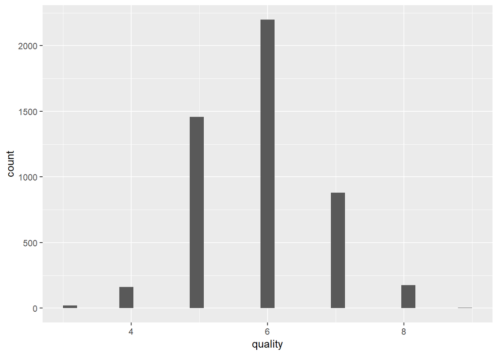

```
##    Min. 1st Qu.  Median    Mean 3rd Qu.    Max.
##   3.000   5.000   6.000   5.878   6.000   9.000
```

I improve the graph to get better comment for this graph by make breaks for the x scale and change the bin width becase this varibale have range between 6 intgers numbers.

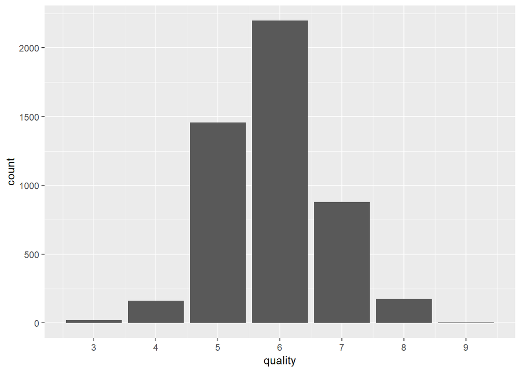

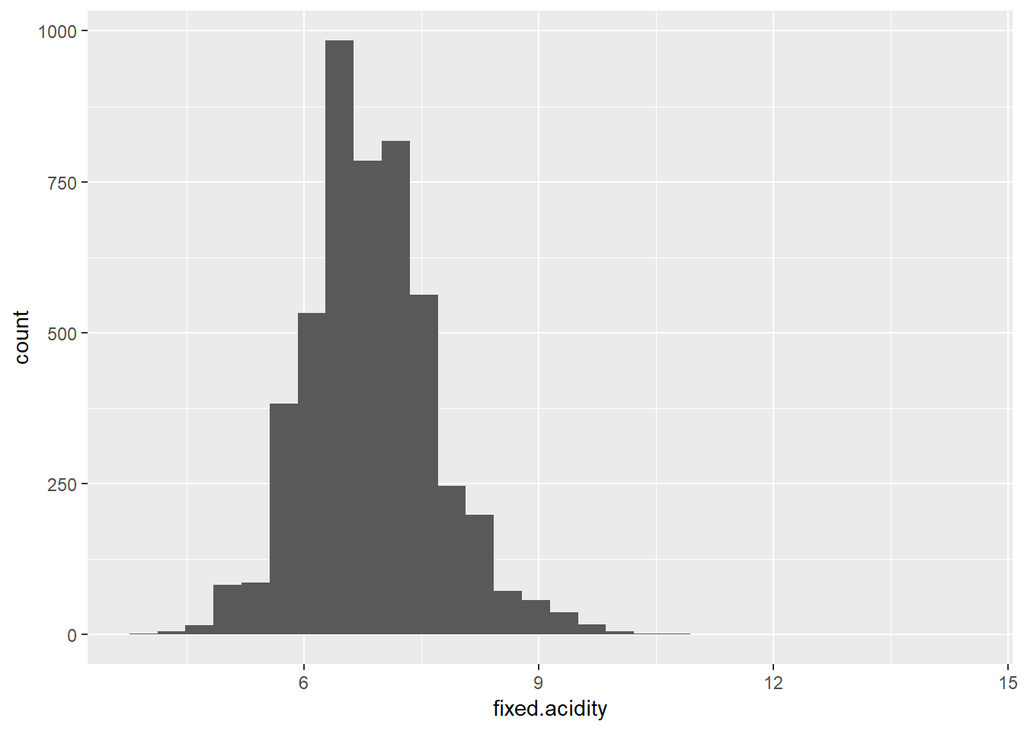

Most of wine have fixed acidity between 5.5 and 8, some variable are outlier values at 12, 14.

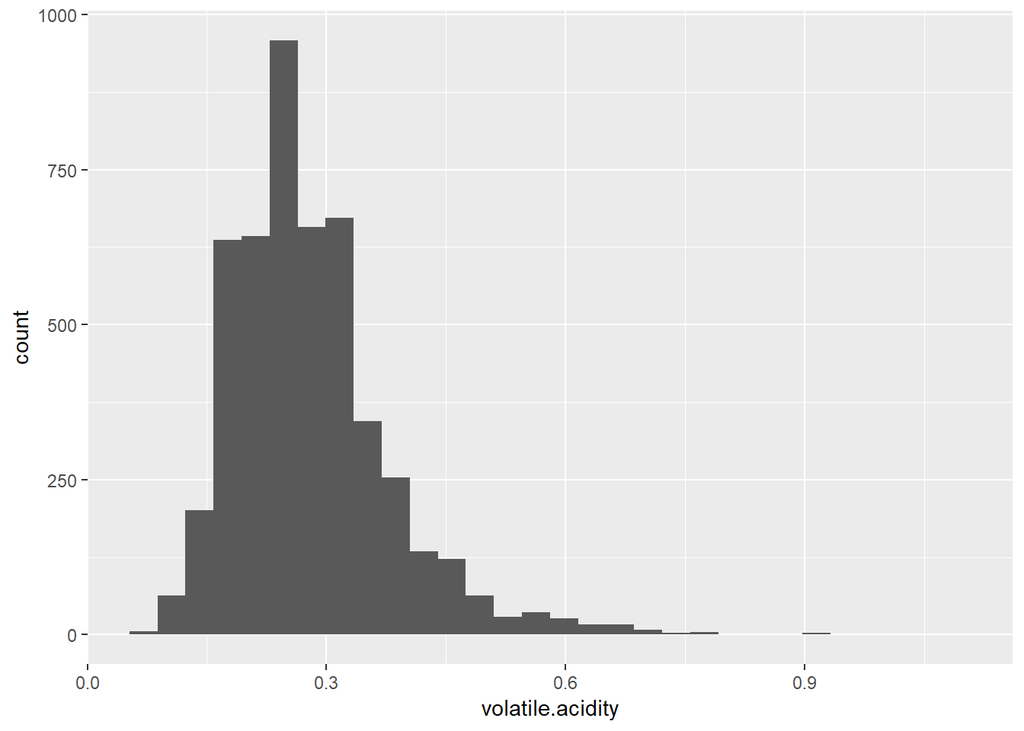

```
##    Min. 1st Qu.  Median    Mean 3rd Qu.    Max.
##  0.0800  0.2100  0.2600  0.2782  0.3200  1.1000
```

Most of wines have volatile.acitdity between 0.15 and .45 and some wines are outliers greater than 0.9.

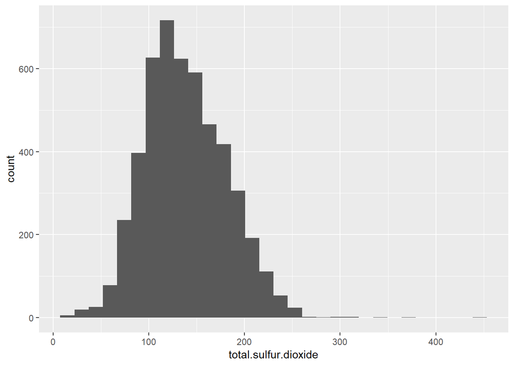

```
##    Min. 1st Qu.  Median    Mean 3rd Qu.    Max.
##     9.0   108.0   134.0   138.4   167.0   440.0
```

Most of wines have total.sulfur.dioxide in range form 100 to 200 and some greater than 280 are outlier.

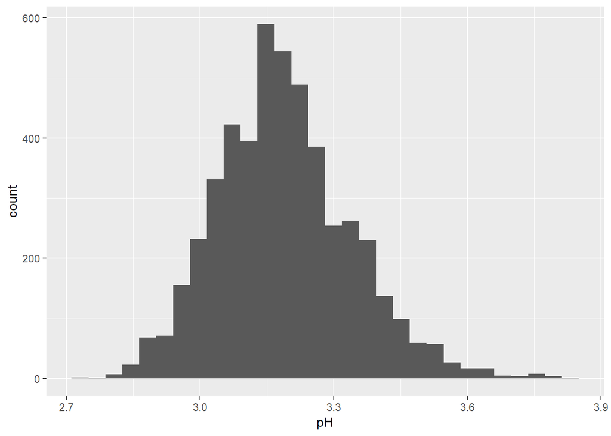

```
##    Min. 1st Qu.  Median    Mean 3rd Qu.    Max.
##   2.720   3.090   3.180   3.188   3.280   3.820
```

Most of wines have pH value between 3 and 3.3.

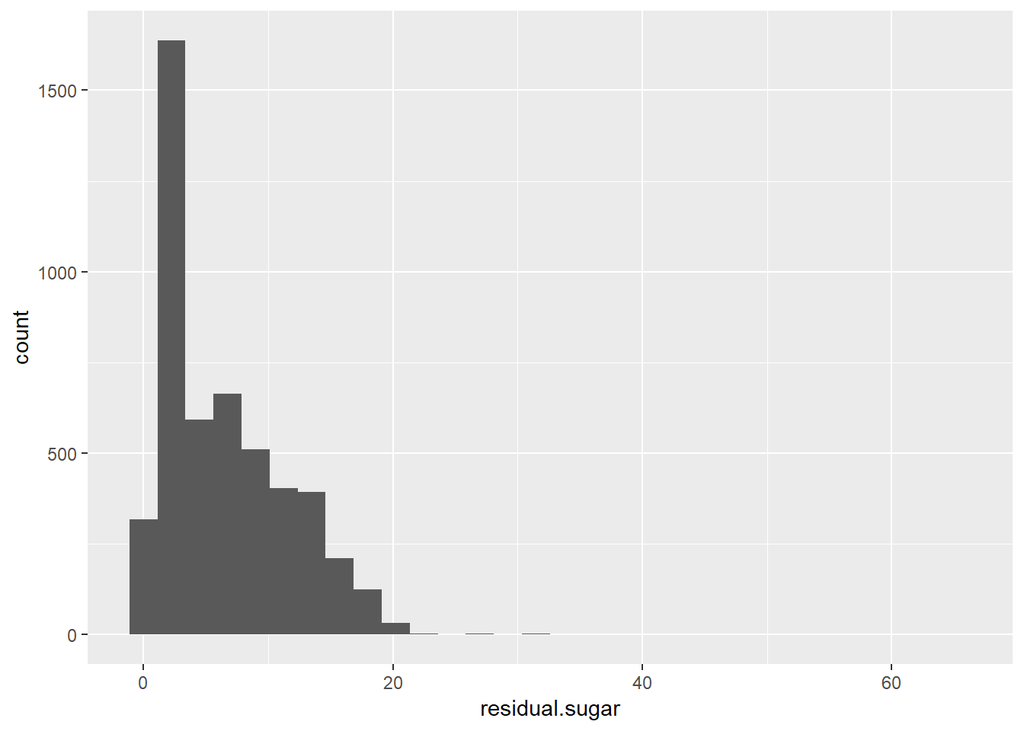

The graph is skewed right and I’ll apply log function to understand the distribution of the variable.

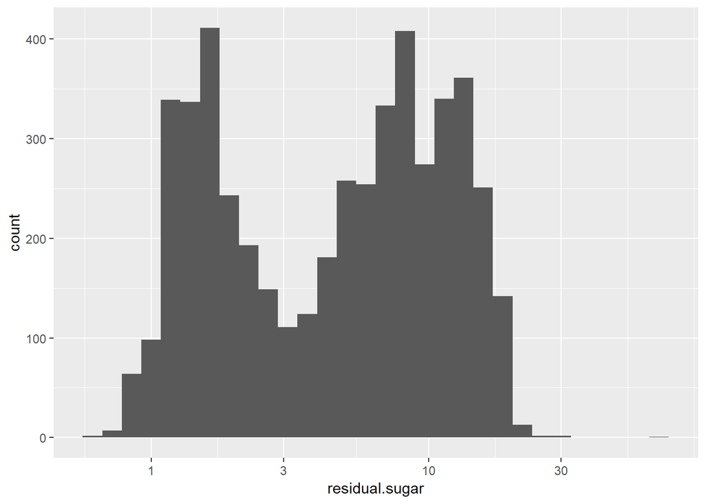

```
##    Min. 1st Qu.  Median    Mean 3rd Qu.    Max.
##   0.600   1.700   5.200   6.391   9.900  65.800
```

I notice the wines are in two group of residual sugar and some values are outliers.

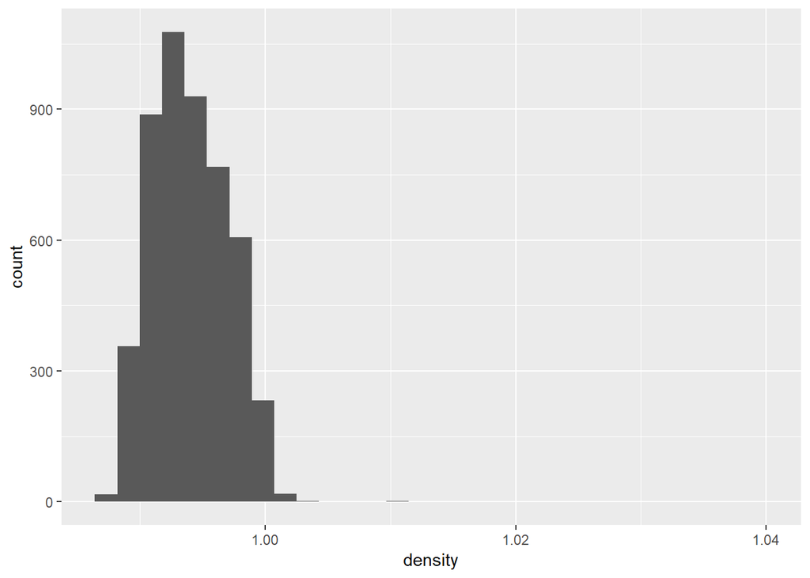

```
##    Min. 1st Qu.  Median    Mean 3rd Qu.    Max.
##  0.9871  0.9917  0.9937  0.9940  0.9961  1.0390
```

The almost of the wines have denisty between 0.98 to 1 and some outliers are larger than 1 and I’ll zoom in the next graph for This region.

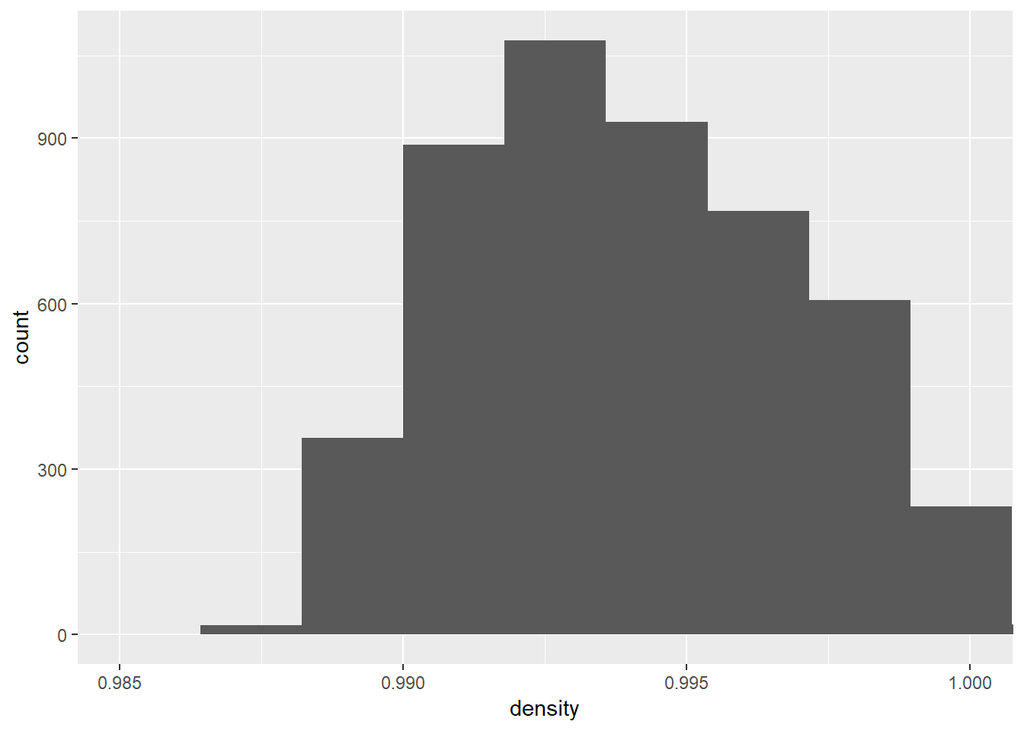

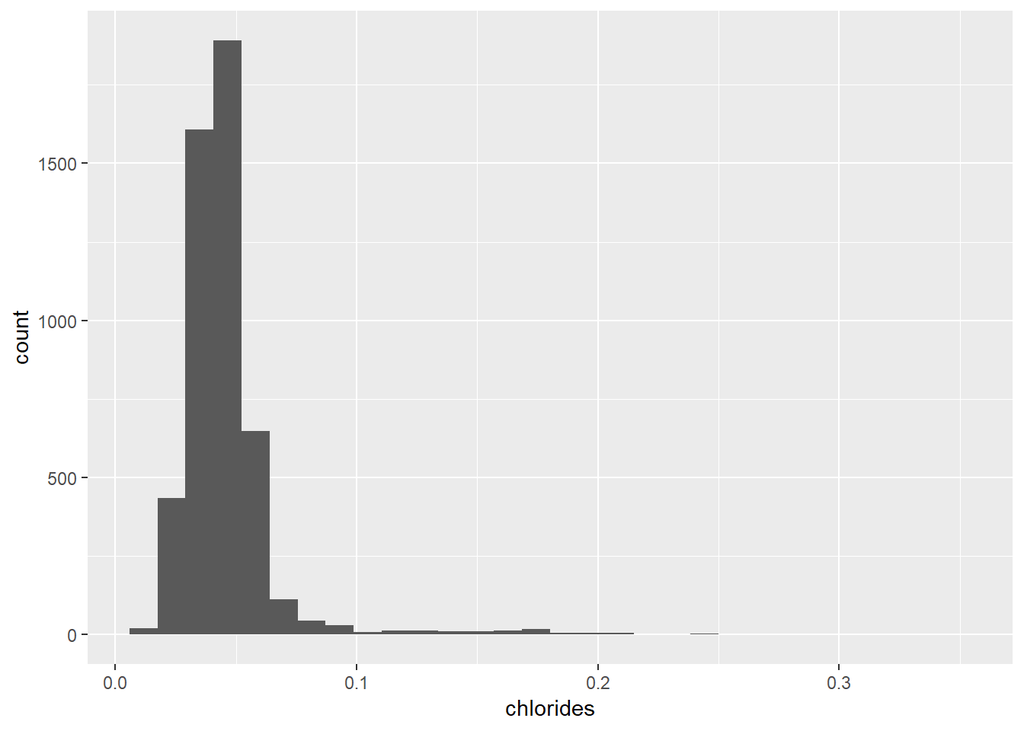

```
##    Min. 1st Qu.  Median    Mean 3rd Qu.    Max.
## 0.00900 0.03600 0.04300 0.04577 0.05000 0.34600
```

The almost of wines have value of chlorides between 0 and 0.1, and I think that chlorides don’t have extremly control on quality grade.

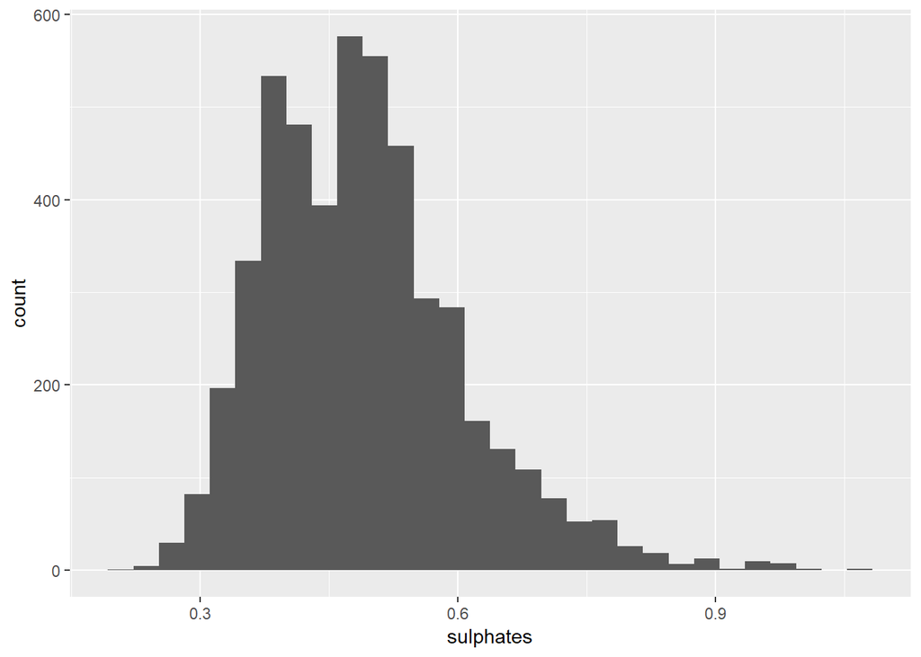

```
##    Min. 1st Qu.  Median    Mean 3rd Qu.    Max.
##  0.2200  0.4100  0.4700  0.4898  0.5500  1.0800
```

Most of wines have sulphates values between 0.35 and 0.6 and some values are outliers.

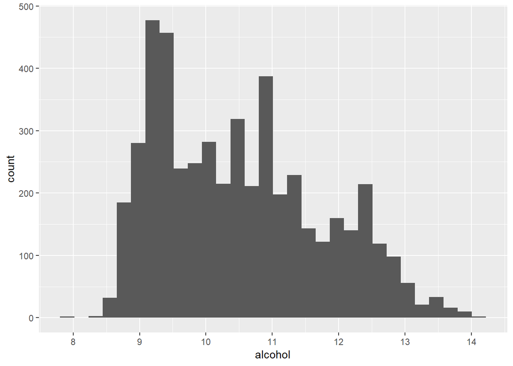

```
##    Min. 1st Qu.  Median    Mean 3rd Qu.    Max.
##    8.00    9.50   10.40   10.51   11.40   14.20
```

Most of wines alcohol value between 9 and 11.5 and I think that alcohol predicting grade of the wine quality.

# Univariate Analysis

### What is the structure of your dataset?

There are 4,898 wines in the dataset with 12 features (fixed.acidity, volatile.acidity, citric.acid, residual.sugar, chlorides, free.sulfur.dioxide, total.sulfur.dioxide, density, pH, sulphates, alcohol, quality).

### Did you create any new variables from existing variables in the dataset?

# Bivariate Plots Section

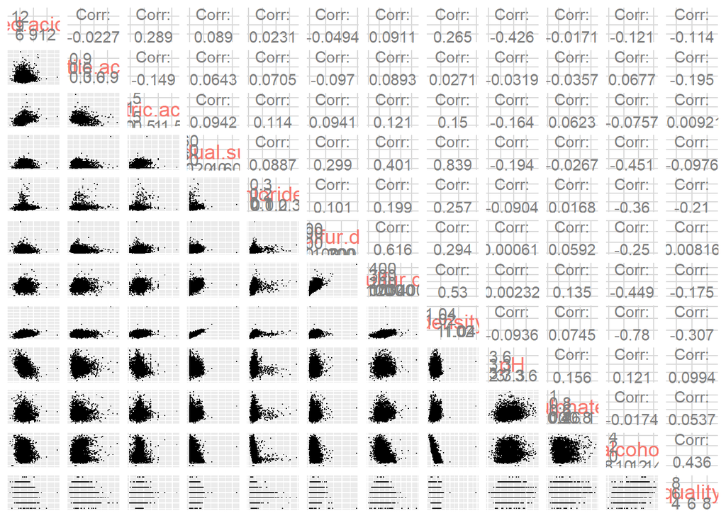

From the data, density, residual.sugar, chlorides, and total.sulfur.dioxide do not seem to have strong correlations with quality, but density is pretty large and residual.sugar, chlorides, and total.sulfurdioxide moderately correlated with alcohol. I want to look closer at scatter plots involving quality and some other variables like alcohol, density, volatile.acidity and residual.sugar.

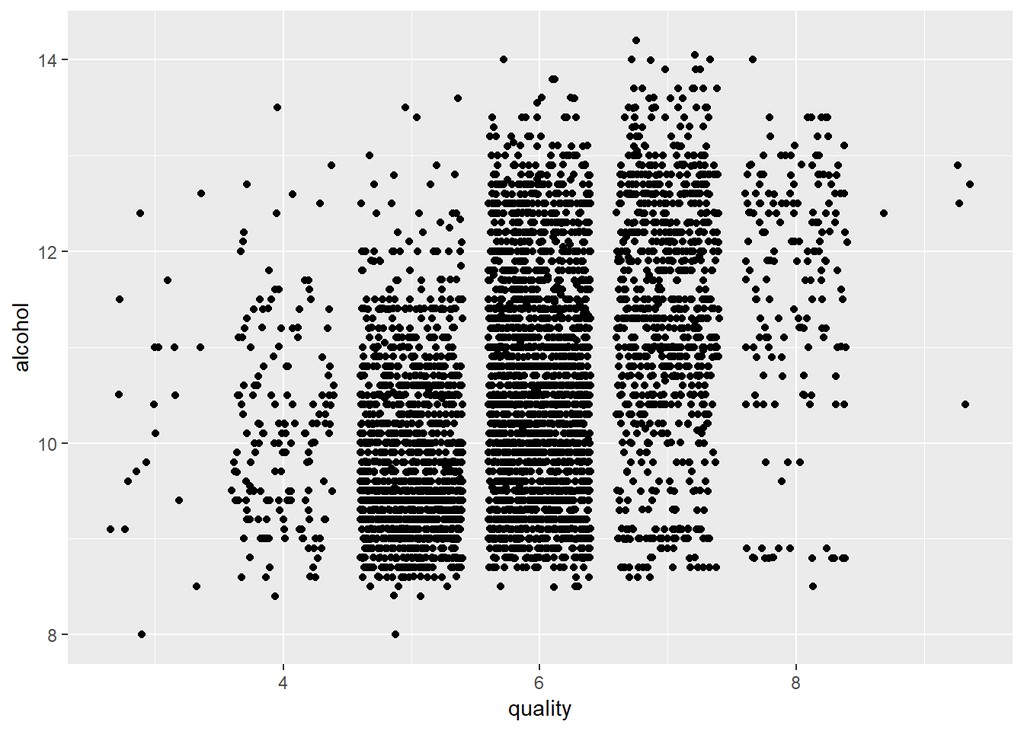

My problem now, I can’t get best relationship in this graph and overplot because the quality is integer numbers then I’ll jitter points on x-axis and put width equal 1 to see some imporve in relationship in points between quality and alcohol and use alpha.

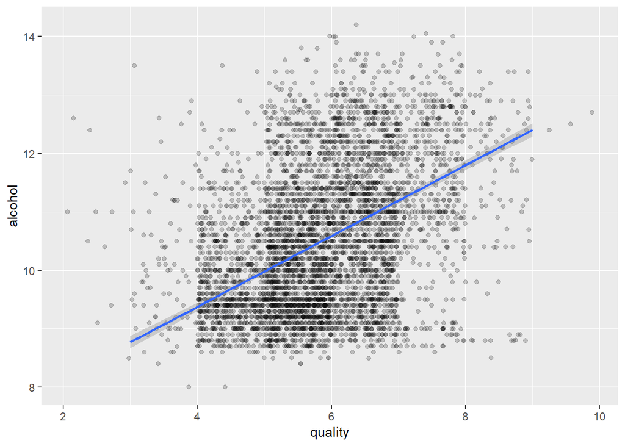

Notice is this pretty good relationship between alcohol and quality, as av the alcohol increases the quality increases.

> Note: Because I make jitter for points in x axis in last graph when I graph quality on x-axis then I make jitter for points in x axis for next graphs between (quality - density) and (quality - residual.sugar)

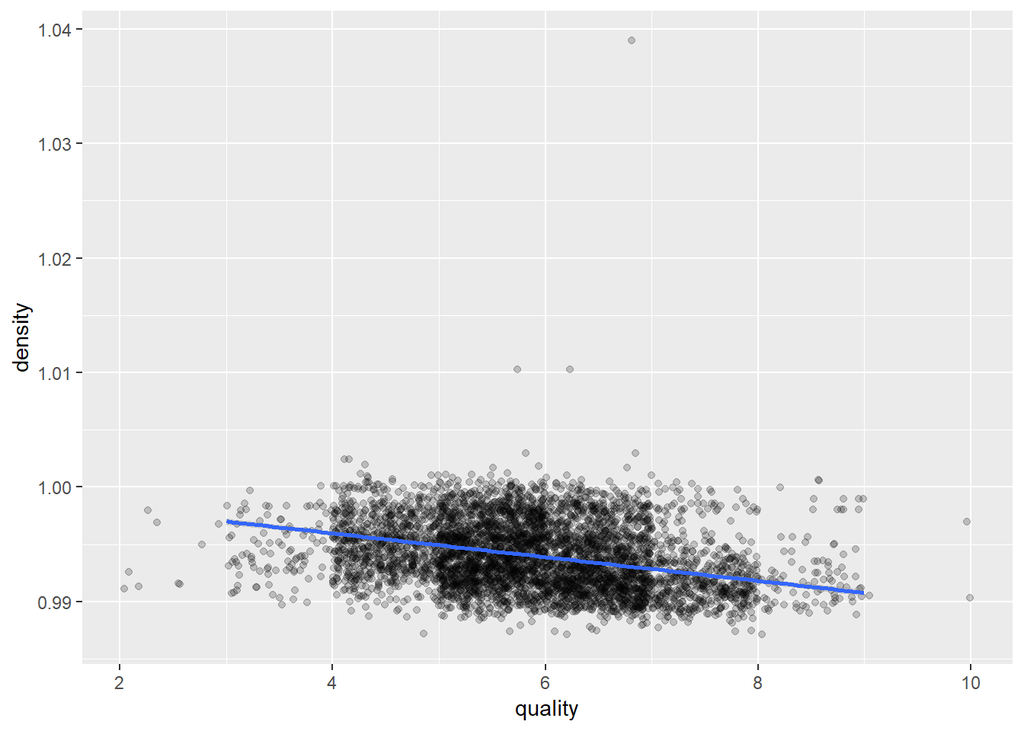

I notice a realtion with density but we have three points outliers on y-axis great than 1.005, then I remove them form next graph to see the relationship between quality and density.

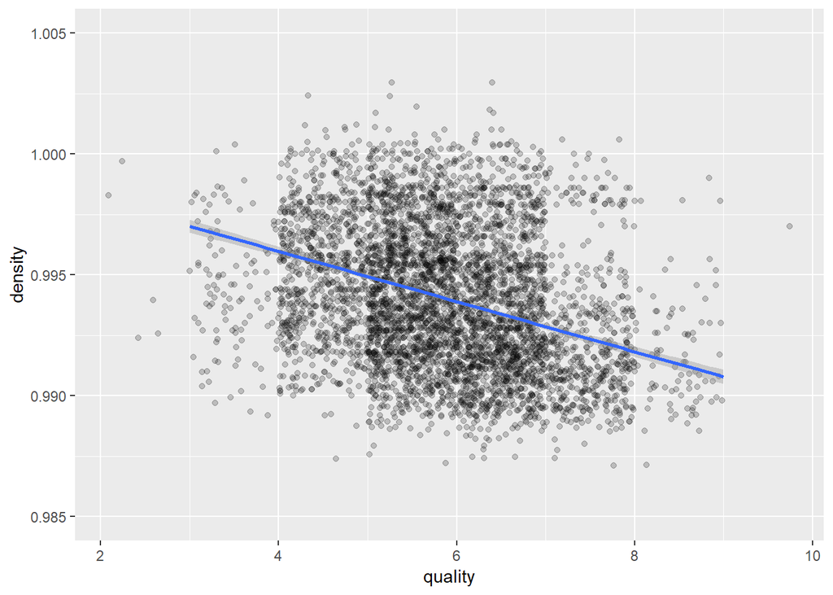

as smooth line when density increases the quality decreases.

> Note: from histogram of residual.sugar in the last section then I’ll transform the residual.sugar variable by log function.

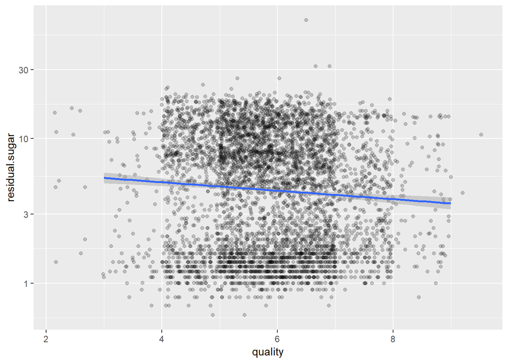

Notice that this very weak realtion ship between quality and residual.sugar.

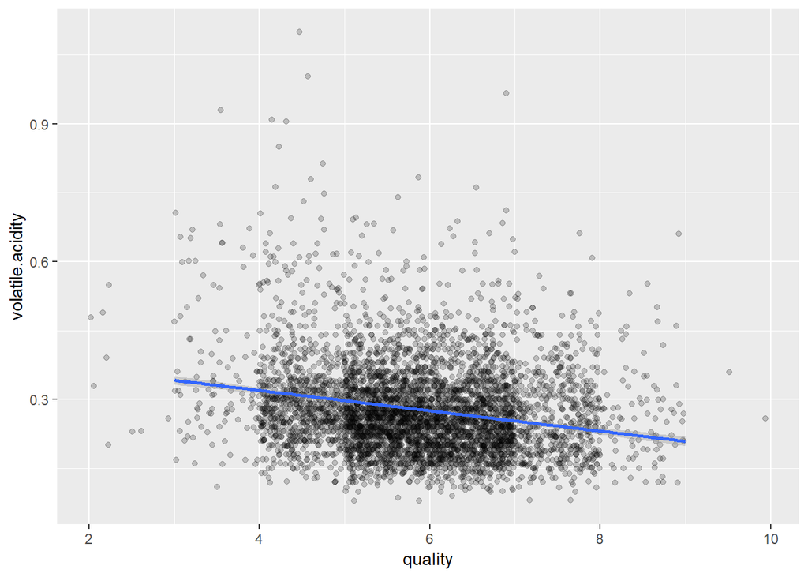

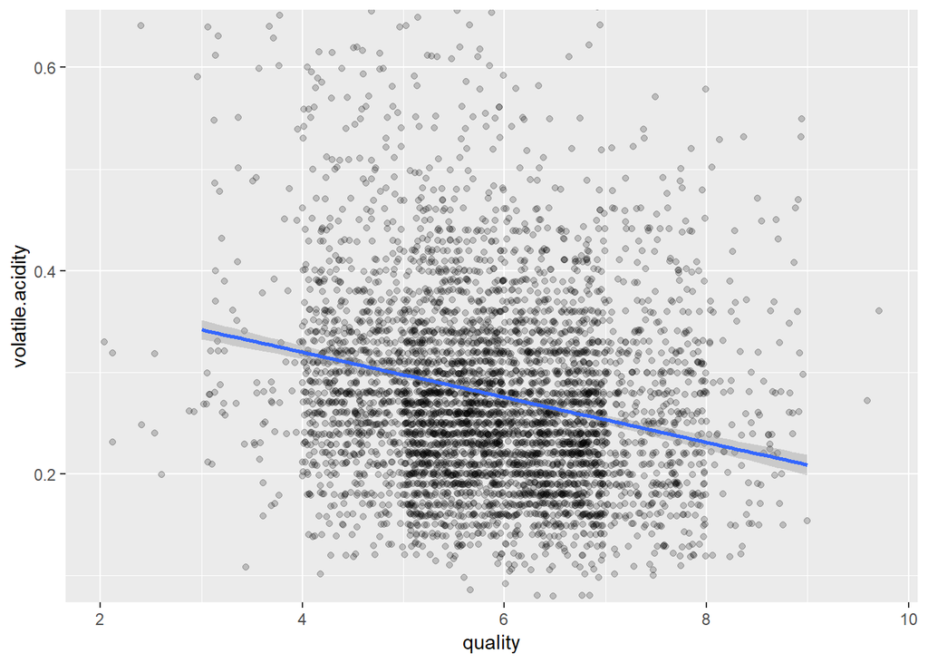

as volatile.acidity increases the grade of quality decreases

Next: density is pretty large and residual.sugar, chlorides, and total.sulfurdioxide moderately correlated with alcohol. I want to look closer at scatter plots involving alcohol and some other variables like density, residual.sugar, chlorides, and total.sulfurdioxide.

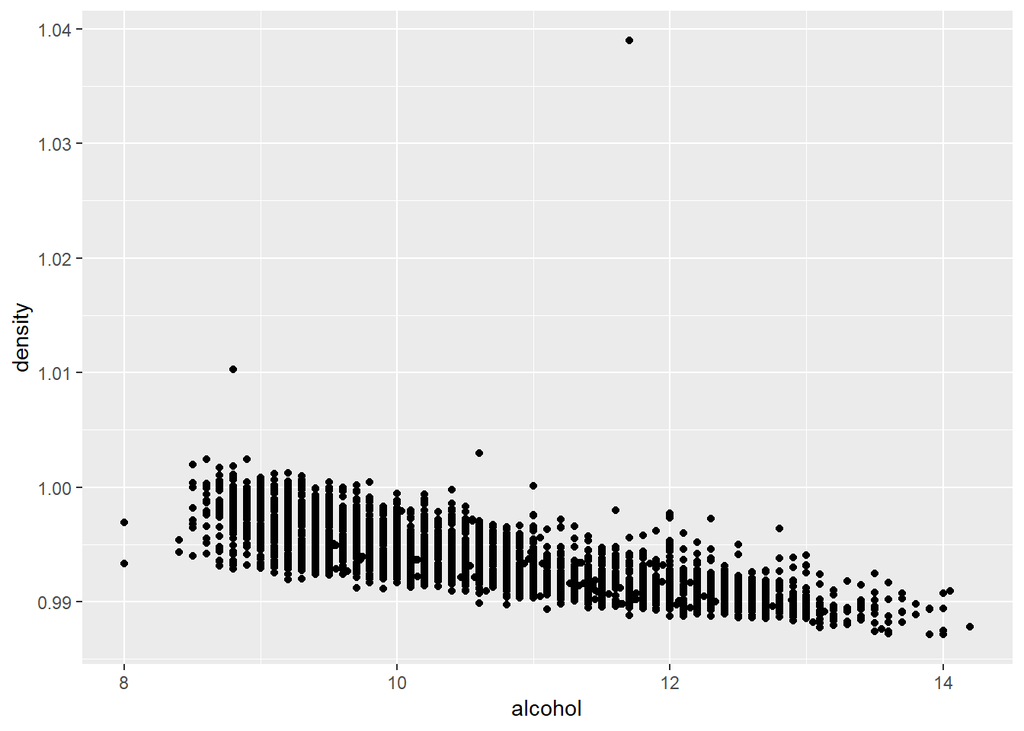

I’ll remove outliers on axis and solve overploting problem by transpering and jitter function.

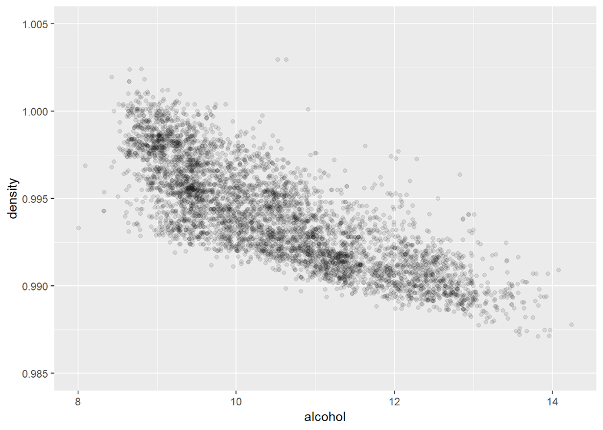

we don’t need to put linear smooth to see the relationship between alcohol and density because it’s pretty large relationship as density increases, alcohol decreases.

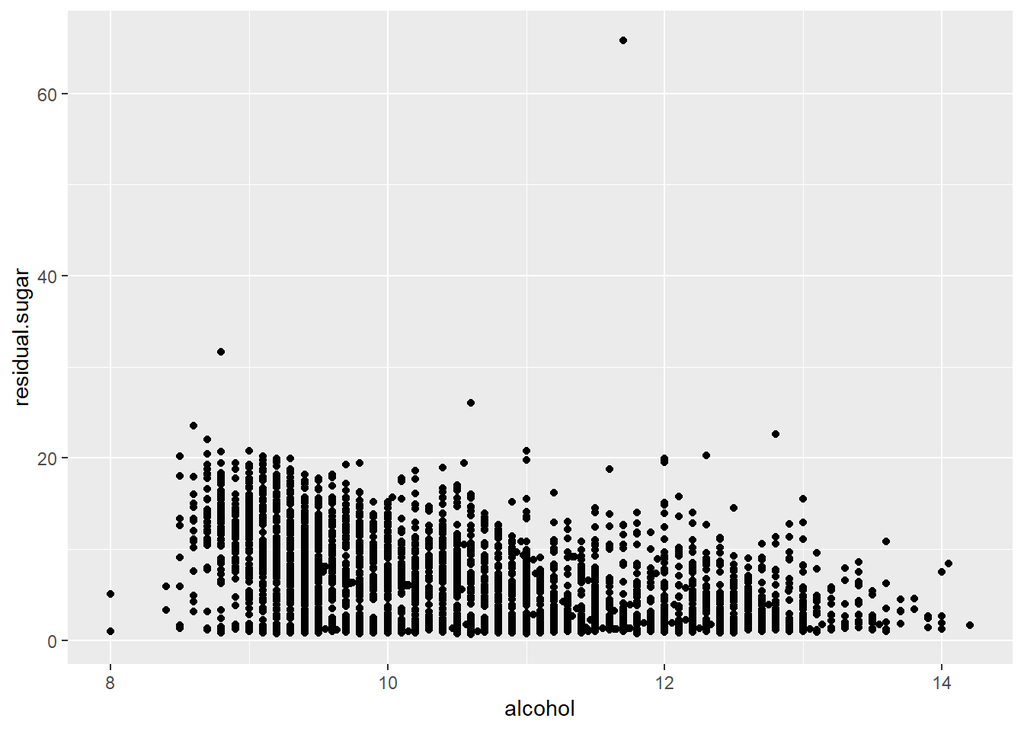

I’ll apply log functioin to residual.sugar variable and apply jitter function and transpiring to solve problem overploting

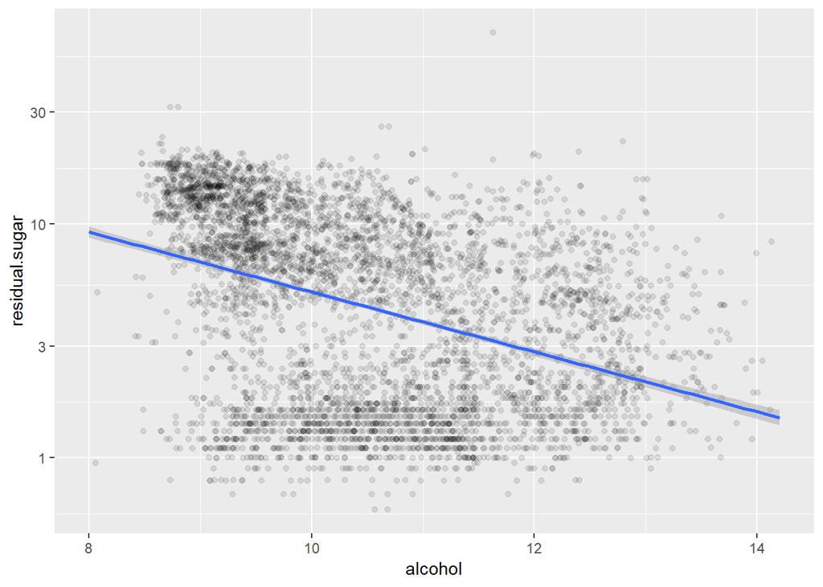

Smooth line is help to understand that “as the residual.sugar increases the alcohol decreases”

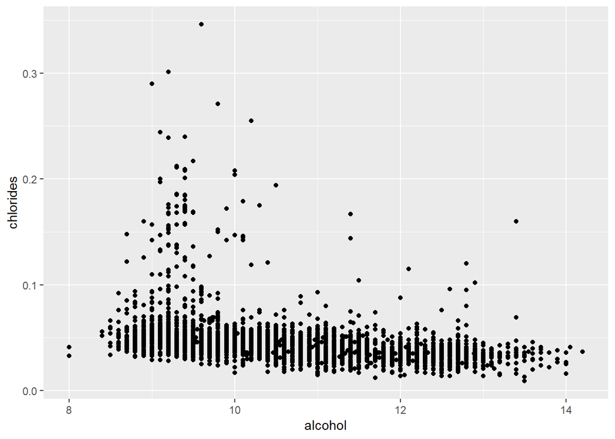

I’ll apply log functioin to chlorides variable and apply jitter function and transpiring to solve problem overploting

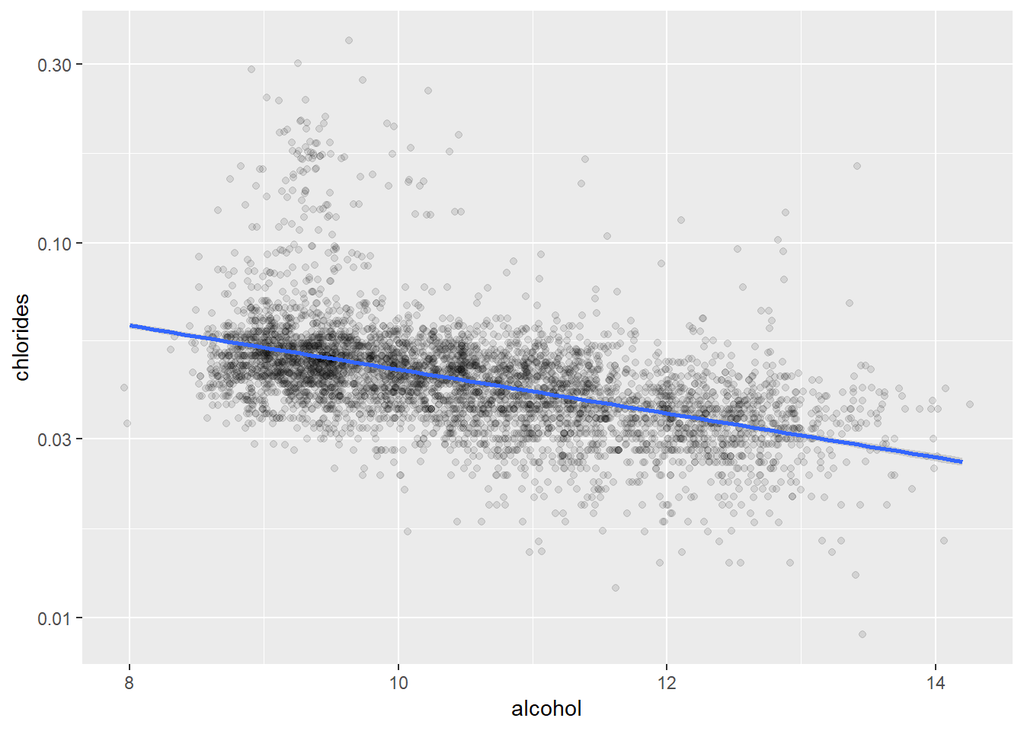

As chlorides increases the alcohol decreases, I notice it by liner smooth model to see this relationship

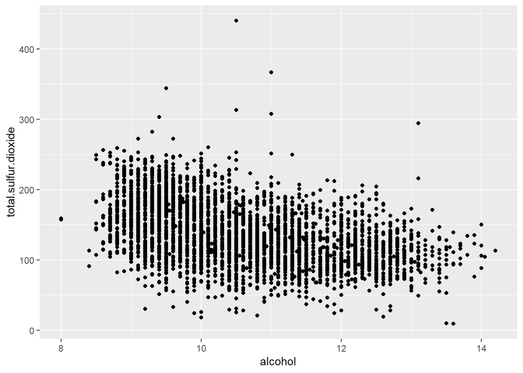

I’ll remove outlier form the y-axis and solve the overploting problem

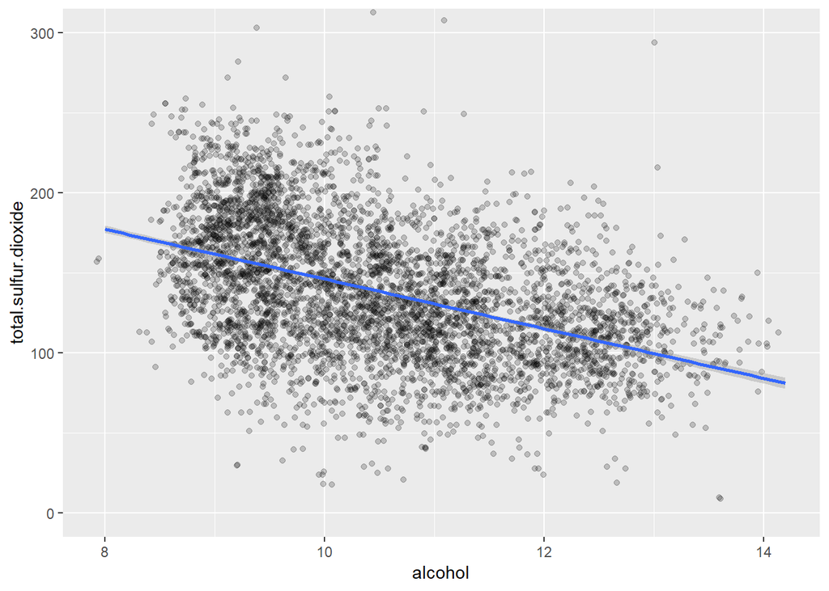

As total.sulfur.dioxide increases the alcohol decreases, I notice it by liner smooth model to see this relationship